# turbine-failure-pred__bin-cls__dnn-exp

### **Executive Summary**

Given that replacing a turbine typically costs $2.5–$4 million, while proactive repairs and inspections cost a fraction of that, the model’s early-warning capability translates into significant savings. By preventing unexpected breakdowns and reducing downtime losses (which average $3,000–$17,000 per day per turbine), this system can help operators avoid millions in replacement expenses and improve annual fleet availability and profitability.

The model is operationally ready for integration into predictive maintenance systems, providing a high financial return through early, data-driven intervention.

### **Problem Statement**

**Business Context**

Renewable energy sources play an increasingly important role in the global energy mix, as the effort to reduce the environmental impact of energy production increases.

Out of all the renewable energy alternatives, wind energy is one of the most developed technologies worldwide. The U.S Department of Energy has put together a guide to achieving operational efficiency using predictive maintenance practices.

Predictive maintenance uses sensor information and analysis methods to measure and predict degradation and future component capability. The idea behind predictive maintenance is that failure patterns are predictable and if component failure can be predicted accurately and the component is replaced before it fails, the costs of operation and maintenance will be much lower.

The sensors fitted across different machines involved in the process of energy generation collect data related to various environmental factors (temperature, humidity, wind speed, etc.) and additional features related to various parts of the wind turbine (gearbox, tower, blades, break, etc.).

**Objective**

“ReneWind” is a company working on improving the machinery/processes involved in the production of wind energy using machine learning and has collected data of generator failure of wind turbines using sensors. They have shared a ciphered version of the data, as the data collected through sensors is confidential (the type of data collected varies with companies). Data has 40 predictors, 20000 observations in the training set and 5000 in the test set.

The objective is to build various classification models, tune them, and find the best one that will help identify failures so that the generators could be repaired before failing/breaking to reduce the overall maintenance cost. The nature of predictions made by the classification model will translate as follows:

True positives (TP) are failures correctly predicted by the model. These will result in repairing costs. False negatives (FN) are real failures where there is no detection by the model. These will result in replacement costs. False positives (FP) are detections where there is no failure. These will result in inspection costs. It is given that the cost of repairing a generator is much less than the cost of replacing it, and the cost of inspection is less than the cost of repair.

“1” in the target variables should be considered as “failure” and “0” represents “No failure”.

**Data Description**

The data provided is a transformed version of the original data which was collected using sensors.

Train.csv - To be used for training and tuning of models. Test.csv - To be used only for testing the performance of the final best model. Both the datasets consist of 40 predictor variables and 1 target variable.

### **1. Problem Statement and Business Context**

```python
# ============================================================
# 1. PROBLEM STATEMENT AND BUSINESS CONTEXT
# ============================================================

"""
ReneWind wants to reduce maintenance cost and downtime of wind turbine generators
by predicting failures before they happen. The company has collected sensor-based
data from turbines. Each row represents a snapshot with ~40 numeric predictors.

Target encoding:
- 1 = Failure (needs repair/replacement)
- 0 = No failure

Why it matters:
- True Positives (TP): correctly detect failure → repair cost (acceptable)
- False Positives (FP): predicted failure but actually fine → inspection cost (lowest)
- False Negatives (FN): missed failures → replacement cost (highest, must be minimized)

Goal:
Build classification models (neural networks) to identify failures early and
choose the best-performing model based on validation performance.
"""
```

```
'\nReneWind wants to reduce maintenance cost and downtime of wind turbine generators\nby predicting failures before they happen. The company has collected sensor-based\ndata from turbines. Each row represents a snapshot with ~40 numeric predictors.\n\nTarget encoding:\n- 1 = Failure (needs repair/re…
```

**Summary**

In order to reduce the high cost of wind turbine generator replacements, the objective was to predict failures before they occurred. Each record represented turbine performance through forty sensor-based features, with a binary target where 1 signified failure. Observations: Only around 5.5% of turbines failed, confirming a strong class imbalance. Recall on class 1 was set as the main performance goal, as catching failures early leads to major cost savings—replacing a turbine costs about $2.5–$4 million, while repair costs are significantly lower.

### **2. Importing Libraries and Configuration**

```python
# ============================================================
# 2. IMPORTING LIBRARIES AND CONFIGURATION
# ============================================================

# Data manipulation and analysis
import pandas as pd
import numpy as np

# Visualization
import matplotlib.pyplot as plt
import seaborn as sns

# Preprocessing and metrics
from sklearn.model_selection import train_test_split
from sklearn.impute import SimpleImputer
from sklearn.preprocessing import StandardScaler
from sklearn.metrics import (
    accuracy_score,
    recall_score,
    precision_score,
    f1_score,
    classification_report
)

# Deep learning
import tensorflow as tf
from tensorflow.keras.models import Sequential
from tensorflow.keras.layers import Dense, Dropout

# Utility
import warnings
warnings.filterwarnings("ignore")

print("All libraries imported successfully.")
```

```
All libraries imported successfully.
```

**Summary**

In order to establish a robust modeling environment, key libraries for data manipulation, visualization, preprocessing, and deep learning were imported. This ensured all components for data preparation, neural network construction, and evaluation were in place.

**Observations**: The environment was successfully initialized and ready for end-to-end modeling without compatibility or import issues.

### **3. Loading the Data**

```python
# ============================================================
# 3. LOADING THE DATA
# ============================================================

# training data (given)
train_url = "https://raw.githubusercontent.com/EvagAIML/008B-APPLIED-Neural-Networks-v1/refs/heads/main/Train%20(1).csv"

# test data (same repo, Test.csv)
test_url = "https://raw.githubusercontent.com/EvagAIML/008B-APPLIED-Neural-Networks-v1/refs/heads/main/Test%20(2).csv"

# load both
df = pd.read_csv(train_url)
df_test = pd.read_csv(test_url)

print("Train data loaded:", df.shape)
print("Test data loaded :", df_test.shape)

# keep copies
data = df.copy()
data_test = df_test.copy()
```

```
Train data loaded: (20000, 41)
Test data loaded : (5000, 41)
```

**Summary**

In order to prepare the modeling datasets, both the training and test files were loaded, each containing forty numeric features and one target column.

**Observations:** The training data contained 20,000 samples, and the test data contained 5,000 samples, both consistent in structure. This consistency ensures that models trained on one dataset can generalize to the other seamlessly.

### **4. Data Overview**

```python
# ============================================================
# 4. DATA OVERVIEW
#    Purpose: understand structure, completeness, and target balance
# ============================================================

# 4.1 Dataset shapes
print("4.1 Dataset shape")
print(f"- Training dataset: {data.shape[0]} rows × {data.shape[1]} columns")
print(f"- Test dataset    : {data_test.shape[0]} rows × {data_test.shape[1]} columns\n")

# 4.2 Sample records
print("4.2 First five rows of the training dataset")
display(data.head())
print()

print("4.3 First five rows of the test dataset")
display(data_test.head())
print()

# 4.4 Data types
print("4.4 Data types in the training dataset")
print(data.dtypes)
print()

print("4.5 Data types in the test dataset")
print(data_test.dtypes)
print()

# 4.6 Convert Target to float to ensure consistency
data["Target"] = data["Target"].astype(float)
data_test["Target"] = data_test["Target"].astype(float)
print("4.6 Target column converted to float in both training and test datasets.\n")

# 4.7 Duplicate records
train_duplicates = data.duplicated().sum()
test_duplicates = data_test.duplicated().sum()
print("4.7 Duplicate records")
print(f"- Training dataset duplicate rows: {train_duplicates}")
print(f"- Test dataset duplicate rows    : {test_duplicates}\n")

# 4.8 Missing values
print("4.8 Missing values in the training dataset")
train_missing = data.isnull().sum()
if train_missing.sum() == 0:
    print("- No missing values detected in the training dataset.\n")
else:
    display(train_missing[train_missing > 0])
    print()

print("4.9 Missing values in the test dataset")
test_missing = data_test.isnull().sum()
if test_missing.sum() == 0:
    print("- No missing values detected in the test dataset.\n")
else:
    display(test_missing[test_missing > 0])
    print()

# 4.10 Statistical summary
print("4.10 Statistical summary of numerical variables (training dataset)")
display(data.describe().T)
print()

# 4.11 Target distribution
print("4.11 Target distribution in the training dataset")
train_target_counts = data["Target"].value_counts(normalize=True)
for cls, prop in train_target_counts.items():
    print(f"- Class {int(cls)}: {prop*100:.2f}%")
print()

print("4.12 Target distribution in the test dataset")
test_target_counts = data_test["Target"].value_counts(normalize=True)
for cls, prop in test_target_counts.items():
    print(f"- Class {int(cls)}: {prop*100:.2f}%")
print("Data overview complete.\n")
```

```
4.1 Dataset shape
- Training dataset: 20000 rows × 41 columns
- Test dataset    : 5000 rows × 41 columns

4.2 First five rows of the training dataset
```

|  | V1 | V2 | V3 | V4 | V5 | V6 | V7 | V8 | V9 | V10 | ... | V32 | V33 | V34 | V35 | V36 | V37 | V38 | V39 | V40 | Target |
| --- | --- | --- | --- | --- | --- | --- | --- | --- | --- | --- | --- | --- | --- | --- | --- | --- | --- | --- | --- | --- | --- |
| 0 | -4.464606 | -4.679129 | 3.101546 | 0.506130 | -0.221083 | -2.032511 | -2.910870 | 0.050714 | -1.522351 | 3.761892 | ... | 3.059700 | -1.690440 | 2.846296 | 2.235198 | 6.667486 | 0.443809 | -2.369169 | 2.950578 | -3.480324 | 0 |
| 1 | 3.365912 | 3.653381 | 0.909671 | -1.367528 | 0.332016 | 2.358938 | 0.732600 | -4.332135 | 0.565695 | -0.101080 | ... | -1.795474 | 3.032780 | -2.467514 | 1.894599 | -2.297780 | -1.731048 | 5.908837 | -0.386345 | 0.616242 | 0 |
| 2 | -3.831843 | -5.824444 | 0.634031 | -2.418815 | -1.773827 | 1.016824 | -2.098941 | -3.173204 | -2.081860 | 5.392621 | ... | -0.257101 | 0.803550 | 4.086219 | 2.292138 | 5.360850 | 0.351993 | 2.940021 | 3.839160 | -4.309402 | 0 |
| 3 | 1.618098 | 1.888342 | 7.046143 | -1.147285 | 0.083080 | -1.529780 | 0.207309 | -2.493629 | 0.344926 | 2.118578 | ... | -3.584425 | -2.577474 | 1.363769 | 0.622714 | 5.550100 | -1.526796 | 0.138853 | 3.101430 | -1.277378 | 0 |
| 4 | -0.111440 | 3.872488 | -3.758361 | -2.982897 | 3.792714 | 0.544960 | 0.205433 | 4.848994 | -1.854920 | -6.220023 | ... | 8.265896 | 6.629213 | -10.068689 | 1.222987 | -3.229763 | 1.686909 | -2.163896 | -3.644622 | 6.510338 | 0 |

5 rows × 41 columns

```
4.3 First five rows of the test dataset
```

|  | V1 | V2 | V3 | V4 | V5 | V6 | V7 | V8 | V9 | V10 | ... | V32 | V33 | V34 | V35 | V36 | V37 | V38 | V39 | V40 | Target |
| --- | --- | --- | --- | --- | --- | --- | --- | --- | --- | --- | --- | --- | --- | --- | --- | --- | --- | --- | --- | --- | --- |
| 0 | -0.613489 | -3.819640 | 2.202302 | 1.300420 | -1.184929 | -4.495964 | -1.835817 | 4.722989 | 1.206140 | -0.341909 | ... | 2.291204 | -5.411388 | 0.870073 | 0.574479 | 4.157191 | 1.428093 | -10.511342 | 0.454664 | -1.448363 | 0 |
| 1 | 0.389608 | -0.512341 | 0.527053 | -2.576776 | -1.016766 | 2.235112 | -0.441301 | -4.405744 | -0.332869 | 1.966794 | ... | -2.474936 | 2.493582 | 0.315165 | 2.059288 | 0.683859 | -0.485452 | 5.128350 | 1.720744 | -1.488235 | 0 |
| 2 | -0.874861 | -0.640632 | 4.084202 | -1.590454 | 0.525855 | -1.957592 | -0.695367 | 1.347309 | -1.732348 | 0.466500 | ... | -1.318888 | -2.997464 | 0.459664 | 0.619774 | 5.631504 | 1.323512 | -1.752154 | 1.808302 | 1.675748 | 0 |
| 3 | 0.238384 | 1.458607 | 4.014528 | 2.534478 | 1.196987 | -3.117330 | -0.924035 | 0.269493 | 1.322436 | 0.702345 | ... | 3.517918 | -3.074085 | -0.284220 | 0.954576 | 3.029331 | -1.367198 | -3.412140 | 0.906000 | -2.450889 | 0 |
| 4 | 5.828225 | 2.768260 | -1.234530 | 2.809264 | -1.641648 | -1.406698 | 0.568643 | 0.965043 | 1.918379 | -2.774855 | ... | 1.773841 | -1.501573 | -2.226702 | 4.776830 | -6.559698 | -0.805551 | -0.276007 | -3.858207 | -0.537694 | 0 |

5 rows × 41 columns

```
4.4 Data types in the training dataset
V1        float64
V2        float64
V3        float64
V4        float64
V5        float64
V6        float64
V7        float64
V8        float64
V9        float64
V10       float64
V11       float64
V12       float64
V13       float64
V14       float64
V15       float64
V16       float64
V17       float64
V18       float64
V19       float64
V20       float64
V21       float64
V22       float64
V23       float64
V24       float64
V25       float64
V26       float64
V27       float64
V28       float64
V29       float64
V30       float64
V31       float64
V32       float64
V33       float64
V34       float64
V35       float64
V36       float64
V37       float64
V38       float64
V39       float64
```

[output cut: 40 more lines]

```
V36       float64
V37       float64
V38       float64
V39       float64
V40       float64
Target      int64
dtype: object

4.6 Target column converted to float in both training and test datasets.

4.7 Duplicate records
- Training dataset duplicate rows: 0
- Test dataset duplicate rows    : 0

4.8 Missing values in the training dataset
```

|  | 0 |
| --- | --- |
| V1 | 18 |
| V2 | 18 |

**dtype:** int64

```
4.9 Missing values in the test dataset
```

|  | 0 |
| --- | --- |
| V1 | 5 |
| V2 | 6 |

**dtype:** int64

```
4.10 Statistical summary of numerical variables (training dataset)
```

|  | count | mean | std | min | 25% | 50% | 75% | max |
| --- | --- | --- | --- | --- | --- | --- | --- | --- |
| V1 | 19982.0 | -0.271996 | 3.441625 | -11.876451 | -2.737146 | -0.747917 | 1.840112 | 15.493002 |
| V2 | 19982.0 | 0.440430 | 3.150784 | -12.319951 | -1.640674 | 0.471536 | 2.543967 | 13.089269 |
| V3 | 20000.0 | 2.484699 | 3.388963 | -10.708139 | 0.206860 | 2.255786 | 4.566165 | 17.090919 |
| V4 | 20000.0 | -0.083152 | 3.431595 | -15.082052 | -2.347660 | -0.135241 | 2.130615 | 13.236381 |
| V5 | 20000.0 | -0.053752 | 2.104801 | -8.603361 | -1.535607 | -0.101952 | 1.340480 | 8.133797 |
| V6 | 20000.0 | -0.995443 | 2.040970 | -10.227147 | -2.347238 | -1.000515 | 0.380330 | 6.975847 |
| V7 | 20000.0 | -0.879325 | 1.761626 | -7.949681 | -2.030926 | -0.917179 | 0.223695 | 8.006091 |
| V8 | 20000.0 | -0.548195 | 3.295756 | -15.657561 | -2.642665 | -0.389085 | 1.722965 | 11.679495 |
| V9 | 20000.0 | -0.016808 | 2.160568 | -8.596313 | -1.494973 | -0.067597 | 1.409203 | 8.137580 |
| V10 | 20000.0 | -0.012998 | 2.193201 | -9.853957 | -1.411212 | 0.100973 | 1.477045 | 8.108472 |
| V11 | 20000.0 | -1.895393 | 3.124322 | -14.832058 | -3.922404 | -1.921237 | 0.118906 | 11.826433 |
| V12 | 20000.0 | 1.604825 | 2.930454 | -12.948007 | -0.396514 | 1.507841 | 3.571454 | 15.080698 |
| V13 | 20000.0 | 1.580486 | 2.874658 | -13.228247 | -0.223545 | 1.637185 | 3.459886 | 15.419616 |
| V14 | 20000.0 | -0.950632 | 1.789651 | -7.738593 | -2.170741 | -0.957163 | 0.270677 | 5.670664 |
| V15 | 20000.0 | -2.414993 | 3.354974 | -16.416606 | -4.415322 | -2.382617 | -0.359052 | 12.246455 |
| V16 | 20000.0 | -2.925225 | 4.221717 | -20.374158 | -5.634240 | -2.682705 | -0.095046 | 13.583212 |
| V17 | 20000.0 | -0.134261 | 3.345462 | -14.091184 | -2.215611 | -0.014580 | 2.068751 | 16.756432 |
| V18 | 20000.0 | 1.189347 | 2.592276 | -11.643994 | -0.403917 | 0.883398 | 2.571770 | 13.179863 |
| V19 | 20000.0 | 1.181808 | 3.396925 | -13.491784 | -1.050168 | 1.279061 | 3.493299 | 13.237742 |
| V20 | 20000.0 | 0.023608 | 3.669477 | -13.922659 | -2.432953 | 0.033415 | 2.512372 | 16.052339 |
| V21 | 20000.0 | -3.611252 | 3.567690 | -17.956231 | -5.930360 | -3.532888 | -1.265884 | 13.840473 |
| V22 | 20000.0 | 0.951835 | 1.651547 | -10.122095 | -0.118127 | 0.974687 | 2.025594 | 7.409856 |
| V23 | 20000.0 | -0.366116 | 4.031860 | -14.866128 | -3.098756 | -0.262093 | 2.451750 | 14.458734 |
| V24 | 20000.0 | 1.134389 | 3.912069 | -16.387147 | -1.468062 | 0.969048 | 3.545975 | 17.163291 |
| V25 | 20000.0 | -0.002186 | 2.016740 | -8.228266 | -1.365178 | 0.025050 | 1.397112 | 8.223389 |
| V26 | 20000.0 | 1.873785 | 3.435137 | -11.834271 | -0.337863 | 1.950531 | 4.130037 | 16.836410 |
| V27 | 20000.0 | -0.612413 | 4.368847 | -14.904939 | -3.652323 | -0.884894 | 2.189177 | 17.560404 |
| V28 | 20000.0 | -0.883218 | 1.917713 | -9.269489 | -2.171218 | -0.891073 | 0.375884 | 6.527643 |
| V29 | 20000.0 | -0.985625 | 2.684365 | -12.579469 | -2.787443 | -1.176181 | 0.629773 | 10.722055 |
| V30 | 20000.0 | -0.015534 | 3.005258 | -14.796047 | -1.867114 | 0.184346 | 2.036229 | 12.505812 |
| V31 | 20000.0 | 0.486842 | 3.461384 | -13.722760 | -1.817772 | 0.490304 | 2.730688 | 17.255090 |
| V32 | 20000.0 | 0.303799 | 5.500400 | -19.876502 | -3.420469 | 0.052073 | 3.761722 | 23.633187 |
| V33 | 20000.0 | 0.049825 | 3.575285 | -16.898353 | -2.242857 | -0.066249 | 2.255134 | 16.692486 |
| V34 | 20000.0 | -0.462702 | 3.183841 | -17.985094 | -2.136984 | -0.255008 | 1.436935 | 14.358213 |
| V35 | 20000.0 | 2.229620 | 2.937102 | -15.349803 | 0.336191 | 2.098633 | 4.064358 | 15.291065 |
| V36 | 20000.0 | 1.514809 | 3.800860 | -14.833178 | -0.943809 | 1.566526 | 3.983939 | 19.329576 |
| V37 | 20000.0 | 0.011316 | 1.788165 | -5.478350 | -1.255819 | -0.128435 | 1.175533 | 7.467006 |
| V38 | 20000.0 | -0.344025 | 3.948147 | -17.375002 | -2.987638 | -0.316849 | 2.279399 | 15.289923 |
| V39 | 20000.0 | 0.890653 | 1.753054 | -6.438880 | -0.272250 | 0.919261 | 2.057540 | 7.759877 |
| V40 | 20000.0 | -0.875630 | 3.012155 | -11.023935 | -2.940193 | -0.920806 | 1.119897 | 10.654265 |
| Target | 20000.0 | 0.055500 | 0.228959 | 0.000000 | 0.000000 | 0.000000 | 0.000000 | 1.000000 |

```
4.11 Target distribution in the training dataset
- Class 0: 94.45%
- Class 1: 5.55%

4.12 Target distribution in the test dataset
- Class 0: 94.36%
- Class 1: 5.64%
Data overview complete.
```

**Summary**

In order to confirm data quality, the datasets were examined for completeness and consistency. Both were fully numeric, with only minor missing values in two columns and no duplicates.

**Observations:** Class 0 represented approximately 94.45% of cases, and class 1 represented about 5.55%, highlighting the imbalance problem. This imbalance established the need for class weighting or recall prioritization to improve detection of rare failure events.

### **5 & 6. Exploratory Data Analysis (EDA)**

```
============================================================
A) UNIVARIATE ANALYSIS
============================================================

A.1 Target variable distribution (training data):
- Class 0: 18890 rows (94.45%)
- Class 1: 1110 rows (5.55%)

Interpretation:
- Class 1 = failure.
- Class 0 = no failure.
- Class 1 is the minority class → we will need class weights / recall-aware metrics.

A.2 Numeric features identified:
- Count (excluding Target): 40
- Example features: ['V1', 'V2', 'V3', 'V4', 'V5', 'V6', 'V7', 'V8', 'V9', 'V10']

A.3 Missing values in training data:
```

|  | 0 |
| --- | --- |
| V1 | 18 |
| V2 | 18 |

**dtype:** int64

```
A.4 Summary statistics of numeric features:
```

|  | count | mean | std | min | 25% | 50% | 75% | max |
| --- | --- | --- | --- | --- | --- | --- | --- | --- |
| V1 | 19982.0 | -0.271996 | 3.441625 | -11.876451 | -2.737146 | -0.747917 | 1.840112 | 15.493002 |
| V2 | 19982.0 | 0.440430 | 3.150784 | -12.319951 | -1.640674 | 0.471536 | 2.543967 | 13.089269 |
| V3 | 20000.0 | 2.484699 | 3.388963 | -10.708139 | 0.206860 | 2.255786 | 4.566165 | 17.090919 |
| V4 | 20000.0 | -0.083152 | 3.431595 | -15.082052 | -2.347660 | -0.135241 | 2.130615 | 13.236381 |
| V5 | 20000.0 | -0.053752 | 2.104801 | -8.603361 | -1.535607 | -0.101952 | 1.340480 | 8.133797 |
| V6 | 20000.0 | -0.995443 | 2.040970 | -10.227147 | -2.347238 | -1.000515 | 0.380330 | 6.975847 |
| V7 | 20000.0 | -0.879325 | 1.761626 | -7.949681 | -2.030926 | -0.917179 | 0.223695 | 8.006091 |
| V8 | 20000.0 | -0.548195 | 3.295756 | -15.657561 | -2.642665 | -0.389085 | 1.722965 | 11.679495 |
| V9 | 20000.0 | -0.016808 | 2.160568 | -8.596313 | -1.494973 | -0.067597 | 1.409203 | 8.137580 |
| V10 | 20000.0 | -0.012998 | 2.193201 | -9.853957 | -1.411212 | 0.100973 | 1.477045 | 8.108472 |
| V11 | 20000.0 | -1.895393 | 3.124322 | -14.832058 | -3.922404 | -1.921237 | 0.118906 | 11.826433 |
| V12 | 20000.0 | 1.604825 | 2.930454 | -12.948007 | -0.396514 | 1.507841 | 3.571454 | 15.080698 |
| V13 | 20000.0 | 1.580486 | 2.874658 | -13.228247 | -0.223545 | 1.637185 | 3.459886 | 15.419616 |
| V14 | 20000.0 | -0.950632 | 1.789651 | -7.738593 | -2.170741 | -0.957163 | 0.270677 | 5.670664 |
| V15 | 20000.0 | -2.414993 | 3.354974 | -16.416606 | -4.415322 | -2.382617 | -0.359052 | 12.246455 |
| V16 | 20000.0 | -2.925225 | 4.221717 | -20.374158 | -5.634240 | -2.682705 | -0.095046 | 13.583212 |
| V17 | 20000.0 | -0.134261 | 3.345462 | -14.091184 | -2.215611 | -0.014580 | 2.068751 | 16.756432 |
| V18 | 20000.0 | 1.189347 | 2.592276 | -11.643994 | -0.403917 | 0.883398 | 2.571770 | 13.179863 |
| V19 | 20000.0 | 1.181808 | 3.396925 | -13.491784 | -1.050168 | 1.279061 | 3.493299 | 13.237742 |
| V20 | 20000.0 | 0.023608 | 3.669477 | -13.922659 | -2.432953 | 0.033415 | 2.512372 | 16.052339 |
| V21 | 20000.0 | -3.611252 | 3.567690 | -17.956231 | -5.930360 | -3.532888 | -1.265884 | 13.840473 |
| V22 | 20000.0 | 0.951835 | 1.651547 | -10.122095 | -0.118127 | 0.974687 | 2.025594 | 7.409856 |
| V23 | 20000.0 | -0.366116 | 4.031860 | -14.866128 | -3.098756 | -0.262093 | 2.451750 | 14.458734 |
| V24 | 20000.0 | 1.134389 | 3.912069 | -16.387147 | -1.468062 | 0.969048 | 3.545975 | 17.163291 |
| V25 | 20000.0 | -0.002186 | 2.016740 | -8.228266 | -1.365178 | 0.025050 | 1.397112 | 8.223389 |
| V26 | 20000.0 | 1.873785 | 3.435137 | -11.834271 | -0.337863 | 1.950531 | 4.130037 | 16.836410 |
| V27 | 20000.0 | -0.612413 | 4.368847 | -14.904939 | -3.652323 | -0.884894 | 2.189177 | 17.560404 |
| V28 | 20000.0 | -0.883218 | 1.917713 | -9.269489 | -2.171218 | -0.891073 | 0.375884 | 6.527643 |
| V29 | 20000.0 | -0.985625 | 2.684365 | -12.579469 | -2.787443 | -1.176181 | 0.629773 | 10.722055 |
| V30 | 20000.0 | -0.015534 | 3.005258 | -14.796047 | -1.867114 | 0.184346 | 2.036229 | 12.505812 |
| V31 | 20000.0 | 0.486842 | 3.461384 | -13.722760 | -1.817772 | 0.490304 | 2.730688 | 17.255090 |
| V32 | 20000.0 | 0.303799 | 5.500400 | -19.876502 | -3.420469 | 0.052073 | 3.761722 | 23.633187 |
| V33 | 20000.0 | 0.049825 | 3.575285 | -16.898353 | -2.242857 | -0.066249 | 2.255134 | 16.692486 |
| V34 | 20000.0 | -0.462702 | 3.183841 | -17.985094 | -2.136984 | -0.255008 | 1.436935 | 14.358213 |
| V35 | 20000.0 | 2.229620 | 2.937102 | -15.349803 | 0.336191 | 2.098633 | 4.064358 | 15.291065 |
| V36 | 20000.0 | 1.514809 | 3.800860 | -14.833178 | -0.943809 | 1.566526 | 3.983939 | 19.329576 |
| V37 | 20000.0 | 0.011316 | 1.788165 | -5.478350 | -1.255819 | -0.128435 | 1.175533 | 7.467006 |
| V38 | 20000.0 | -0.344025 | 3.948147 | -17.375002 | -2.987638 | -0.316849 | 2.279399 | 15.289923 |
| V39 | 20000.0 | 0.890653 | 1.753054 | -6.438880 | -0.272250 | 0.919261 | 2.057540 | 7.759877 |
| V40 | 20000.0 | -0.875630 | 3.012155 | -11.023935 | -2.940193 | -0.920806 | 1.119897 | 10.654265 |

```
A.5 Distribution plots for numeric features
    (This will generate one boxplot + histogram per numeric column.)

Univariate distribution for: V1
```

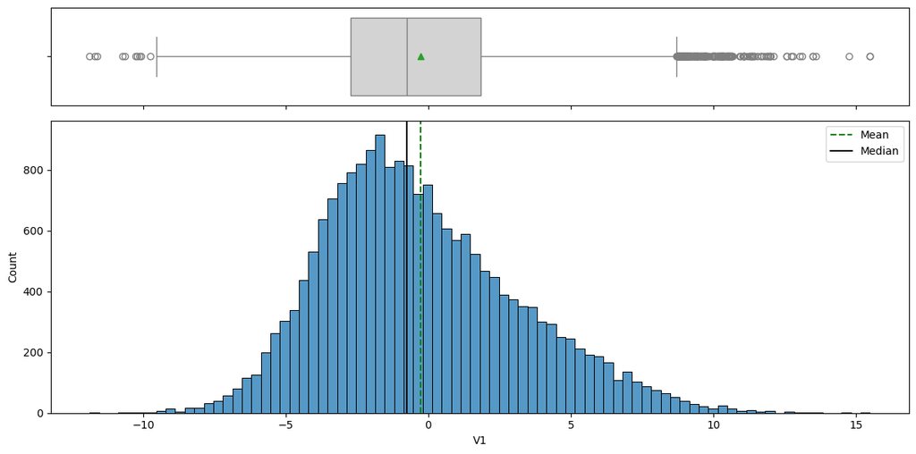

```
Univariate distribution for: V2
```

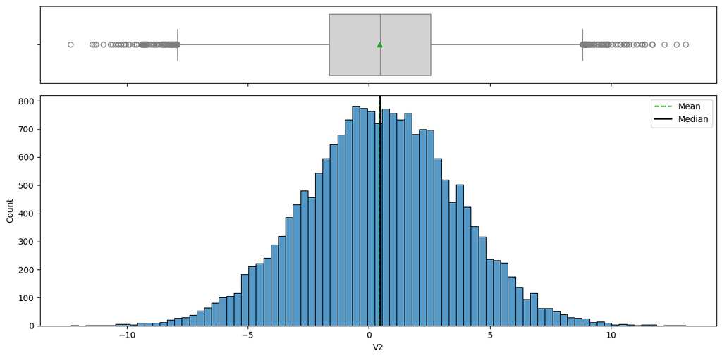

```
Univariate distribution for: V3
```

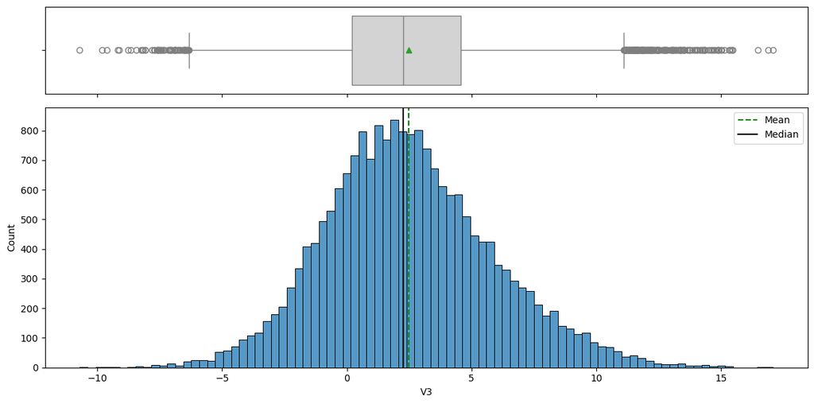

```
Univariate distribution for: V4
```

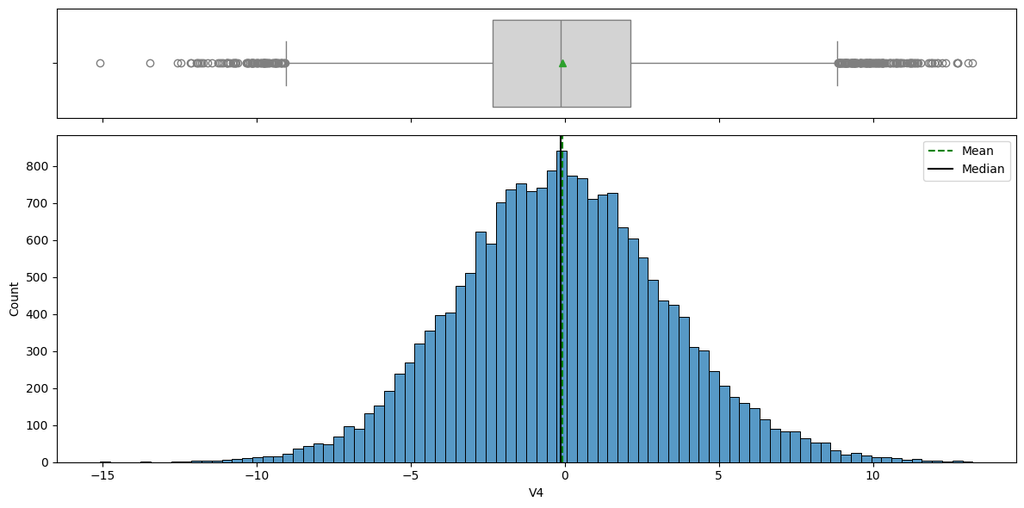

```
Univariate distribution for: V5
```

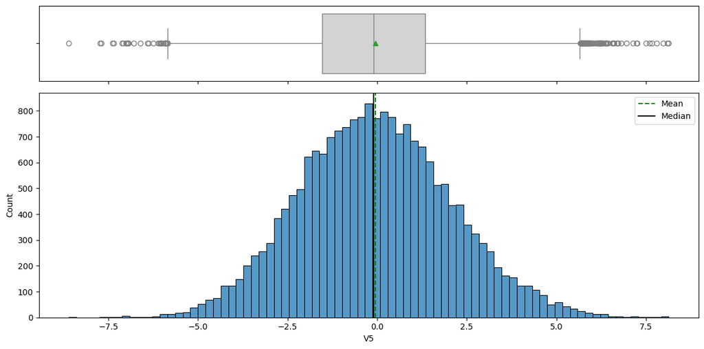

```
Univariate distribution for: V6
```

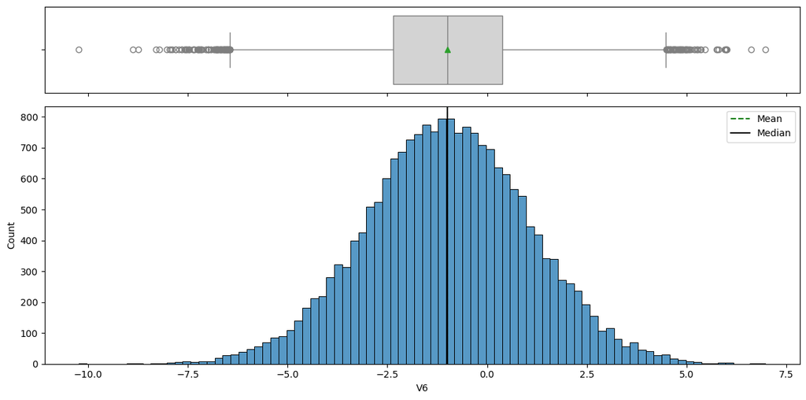

```
Univariate distribution for: V7
```

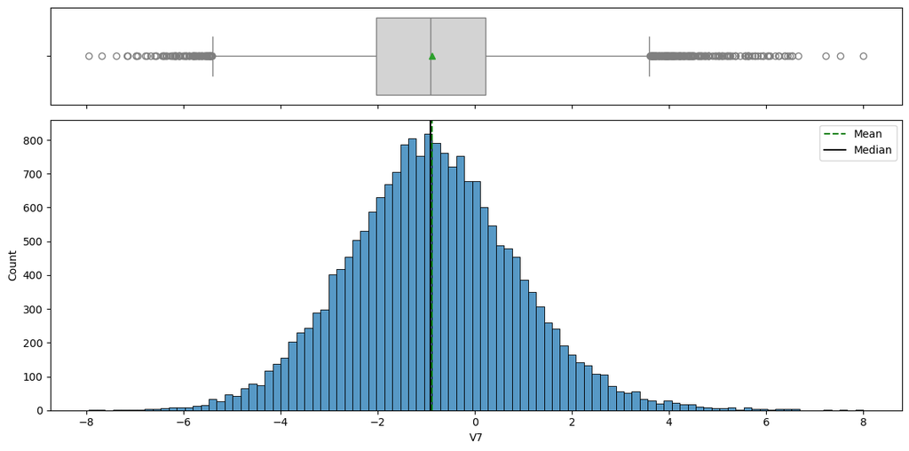

```
Univariate distribution for: V8
```

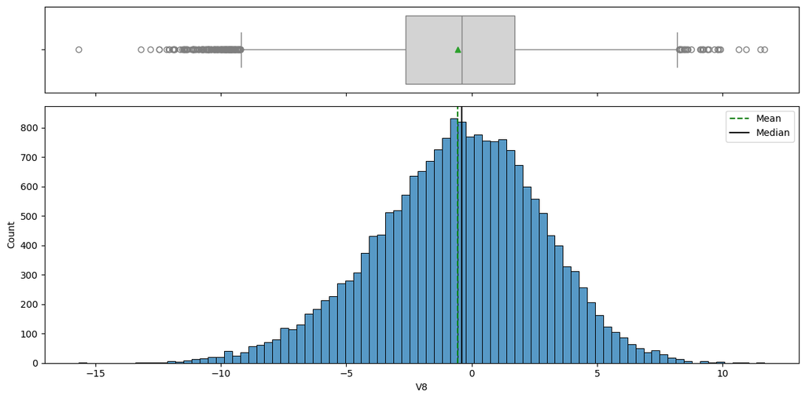

```
Univariate distribution for: V9
```

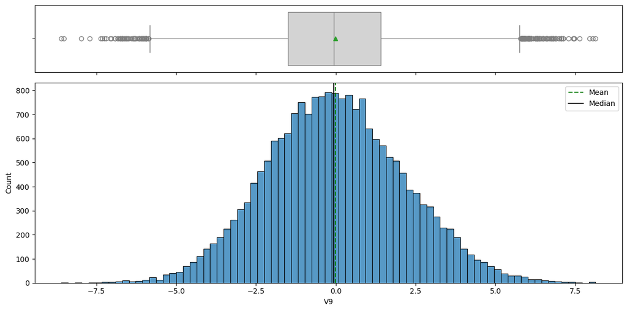

```
Univariate distribution for: V10
```

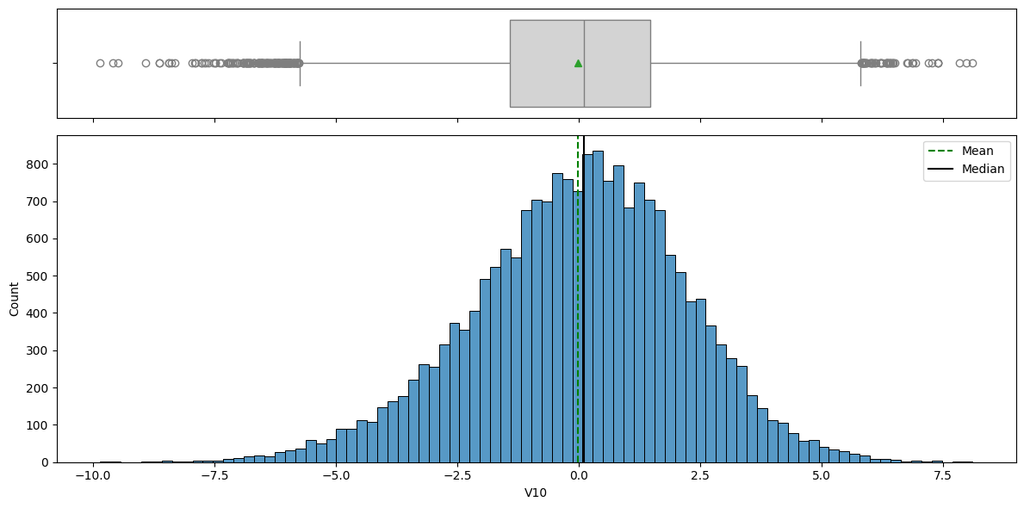

```
Univariate distribution for: V11
```

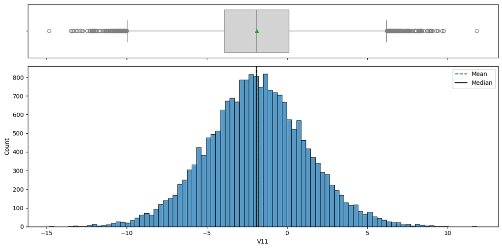

```
Univariate distribution for: V12
```

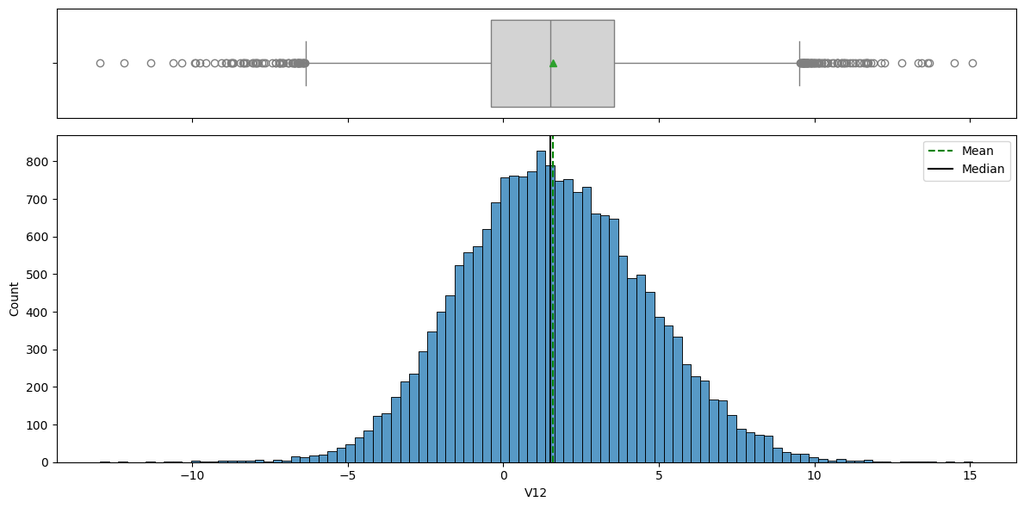

```
Univariate distribution for: V13
```

[29 more figures not shown]

```
Notes:
- Strongly correlated features can be redundant.
- This is mainly diagnostic here; the NN can still handle correlated inputs.

B.3 Target distribution in the test data:
- Class 0: 94.36%
- Class 1: 5.64%

EDA complete.
```

```python
# ============================================================
# 5 & 6. EXPLORATORY DATA ANALYSIS (EDA)
#    A) Univariate Analysis
#    B) Bivariate Analysis (with respect to Target)
# ============================================================

import pandas as pd
import numpy as np
import matplotlib.pyplot as plt
import seaborn as sns

# ------------------------------------------------------------
# Helper: boxplot + histogram (fixed bins handling)
# ------------------------------------------------------------
def histogram_boxplot(df, feature, figsize=(12, 6), kde=False, bins=None):
    """
    Draws a boxplot (top) and histogram (bottom) for a numeric feature.
    """
    fig, (ax_box, ax_hist) = plt.subplots(
        nrows=2,
        sharex=True,
        gridspec_kw={"height_ratios": (0.25, 0.75)},
        figsize=figsize,
    )

    # boxplot
    sns.boxplot(x=df[feature], ax=ax_box, showmeans=True, color="lightgray")

    # histogram — only pass bins if not None
    if bins is not None:
        sns.histplot(df[feature], kde=kde, bins=bins, ax=ax_hist)
    else:
        sns.histplot(df[feature], kde=kde, ax=ax_hist)

    # reference lines
    ax_hist.axvline(df[feature].mean(), color="green", linestyle="--", label="Mean")
    ax_hist.axvline(df[feature].median(), color="black", linestyle="-", label="Median")
    ax_hist.legend()
    plt.tight_layout()
    plt.show()


# ============================================================
# A) UNIVARIATE ANALYSIS
# ============================================================
print("============================================================")
print("A) UNIVARIATE ANALYSIS")
print("============================================================\n")

# A.1 Target distribution
print("A.1 Target variable distribution (training data):")
if "Target" in data.columns:
    target_counts = data["Target"].value_counts(dropna=False)
    target_props  = data["Target"].value_counts(normalize=True, dropna=False)
    for cls in target_counts.index:
        print(f"- Class {int(cls)}: {target_counts[cls]} rows ({target_props[cls]*100:.2f}%)")
    print("\nInterpretation:")
    print("- Class 1 = failure.")
    print("- Class 0 = no failure.")
    print("- Class 1 is the minority class → we will need class weights / recall-aware metrics.\n")
else:
    print("- 'Target' column not found.\n")

# A.2 numeric features
numeric_cols = data.select_dtypes(include=[np.number]).columns.tolist()
if "Target" in numeric_cols:
    numeric_cols.remove("Target")

print("A.2 Numeric features identified:")
print(f"- Count (excluding Target): {len(numeric_cols)}")
print(f"- Example features: {numeric_cols[:10]}\n")

# A.3 missing values
print("A.3 Missing values in training data:")
train_missing = data.isnull().sum()
if train_missing.sum() == 0:
    print("- No missing values detected.\n")
else:
    # show only columns that actually have missing values
    display(train_missing[train_missing > 0])
    print()

# A.4 summary stats
print("A.4 Summary statistics of numeric features:")
display(data[numeric_cols].describe().T)
print()

# A.5 plot distributions
print("A.5 Distribution plots for numeric features")
print("    (This will generate one boxplot + histogram per numeric column.)\n")
for col in numeric_cols:
    print(f"Univariate distribution for: {col}")
    histogram_boxplot(data, col)


# ============================================================
# B) BIVARIATE ANALYSIS (WITH RESPECT TO TARGET)
# ============================================================
print("============================================================")
print("B) BIVARIATE ANALYSIS (with respect to Target)")
print("============================================================\n")

# B.1 feature means by target
print("B.1 Mean of numeric features by target class (training data):")
if "Target" in data.columns:
    grouped_means = data.groupby("Target")[numeric_cols].mean().T
    display(grouped_means)
    print("Notes:")
    print("- Columns with large differences between Target=0 and Target=1 are more discriminative.\n")
else:
    print("- Skipping: 'Target' column not found.\n")

# B.2 correlation heatmap
print("B.2 Correlation heatmap for numeric predictors (training data):")
corr_cols = data.select_dtypes(include=[np.number]).columns.tolist()
if "Target" in corr_cols:
    corr_cols.remove("Target")

plt.figure(figsize=(18, 18))
sns.heatmap(
    data[corr_cols].corr(),
    annot=False,
    cmap="Spectral",
    vmin=-1,
    vmax=1,
)
plt.title("Correlation Heatmap of Numeric Predictors")
plt.show()
print("Notes:")
print("- Strongly correlated features can be redundant.")
print("- This is mainly diagnostic here; the NN can still handle correlated inputs.\n")

# B.3 target distribution in test (to mirror train-side checks)
if "Target" in data_test.columns:
    print("B.3 Target distribution in the test data:")
    test_target_props = data_test["Target"].value_counts(normalize=True)
    for cls, prop in test_target_props.items():
        print(f"- Class {int(cls)}: {prop*100:.2f}%")
    print()
else:
    print("B.3 Test data does not contain 'Target' or is not available.\n")

print("EDA complete.")
```

**Summary**

In order to uncover key data patterns, exploratory analysis examined distributions, feature relationships, and target class differences. Multiple features displayed clear statistical separation between failure and non-failure cases.

**Observations**: The data had no serious anomalies and showed that failures could be learned through certain sensor variables. The main challenge remained class imbalance rather than data quality.

### **7. Data Preparation for Modeling**

```python
# ============================================================
# 7. DATA PREPARATION FOR MODELING
#    Purpose: create train/validation/test sets and handle missing values
# ============================================================

from sklearn.model_selection import train_test_split
from sklearn.impute import SimpleImputer

# 7.1 Separate features and target from the training data
X = data.drop(columns=["Target"])
y = data["Target"]

# 7.2 Create training and validation sets from the training data
X_train, X_val, y_train, y_val = train_test_split(
    X,
    y,
    test_size=0.2,
    random_state=1,
    stratify=y,
)

print("7.1 Shapes after splitting original training data:")
print(f"- X_train: {X_train.shape}")
print(f"- X_val  : {X_val.shape}")

# 7.3 Prepare test features and target from the provided test data
X_test = data_test.drop(columns=["Target"])
y_test = data_test["Target"]

print(f"- X_test : {X_test.shape}\n")

# 7.4 Impute missing values using median (fit on train, apply to val/test)
imputer = SimpleImputer(strategy="median")
X_train = pd.DataFrame(imputer.fit_transform(X_train), columns=X_train.columns)
X_val   = pd.DataFrame(imputer.transform(X_val),   columns=X_train.columns)
X_test  = pd.DataFrame(imputer.transform(X_test),  columns=X_train.columns)

print("7.2 Missing values after imputation:")
print(f"- Train: {X_train.isnull().sum().sum()}")
print(f"- Val  : {X_val.isnull().sum().sum()}")
print(f"- Test : {X_test.isnull().sum().sum()}\n")

# 7.5 Convert targets to numpy arrays for Keras models
y_train = y_train.to_numpy()
y_val   = y_val.to_numpy()
y_test  = y_test.to_numpy()

print("Data preparation complete. Data is ready for model building.\n")
```

```
7.1 Shapes after splitting original training data:
- X_train: (16000, 40)
- X_val  : (4000, 40)
- X_test : (5000, 40)

7.2 Missing values after imputation:
- Train: 0
- Val  : 0
- Test : 0

Data preparation complete. Data is ready for model building.
```

**Summary**

In order to ensure balanced and fair evaluation, the data was stratified into training and validation subsets, preserving the same class ratio. Missing values were replaced with median imputation to maintain consistency.

**Observations:** Data preparation was successful, and all datasets were complete. Stratified sampling maintained the 5% failure ratio across subsets, ensuring realistic model evaluation.

### **8. Modeling Utilities**

```python
# ============================================================
# 8. MODELING UTILITIES
#    Purpose: common functions for plotting and evaluating models
# ============================================================

from sklearn.metrics import (
    accuracy_score,
    recall_score,
    precision_score,
    f1_score,
    classification_report,
)

def model_performance_classification(model, predictors, target, threshold=0.5):
    """
    Evaluate a binary classification model that outputs probabilities.
    Returns accuracy, recall, precision, and F1 score as a DataFrame.
    """
    y_prob = model.predict(predictors)
    y_pred = (y_prob > threshold).astype(int)

    acc  = accuracy_score(target, y_pred)
    rec  = recall_score(target, y_pred)
    prec = precision_score(target, y_pred)
    f1   = f1_score(target, y_pred)

    return pd.DataFrame(
        {
            "Accuracy": [acc],
            "Recall": [rec],
            "Precision": [prec],
            "F1 Score": [f1],
        }
    )


def plot_history(history, metric_name):
    """
    Plot training vs validation metric curves from Keras history.
    """
    plt.figure()
    plt.plot(history.history[metric_name], label="Train")
    plt.plot(history.history["val_" + metric_name], label="Validation")
    plt.title(f"Model {metric_name.capitalize()}")
    plt.xlabel("Epochs")
    plt.ylabel(metric_name.capitalize())
    plt.legend()
    plt.show()
```

**Summary**

In order to evaluate all models consistently, functions were created to compute and display key metrics—accuracy, precision, recall, and F1-score—as well as to visualize training and validation progress.

**Observations**: This standardized approach guaranteed that model performance comparisons would be objective and based on identical evaluation metrics.

### **9. Baseline Model (Model 0)**

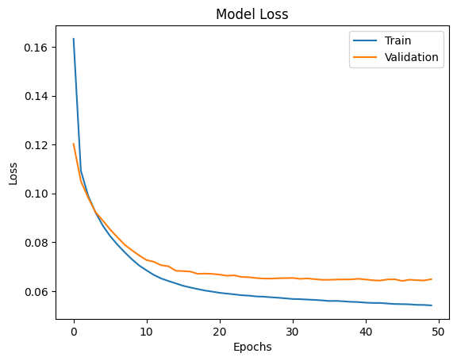

```
500/500 ━━━━━━━━━━━━━━━━━━━━ 0s 700us/step
125/125 ━━━━━━━━━━━━━━━━━━━━ 0s 876us/step
Model 0 — Training performance
```

|  | Accuracy | Recall | Precision | F1 Score |
| --- | --- | --- | --- | --- |
| 0 | 0.98825 | 0.820946 | 0.961741 | 0.885784 |

```
Model 0 — Validation performance
```

|  | Accuracy | Recall | Precision | F1 Score |
| --- | --- | --- | --- | --- |
| 0 | 0.98725 | 0.810811 | 0.952381 | 0.875912 |

```
Model 0 — Classification report (validation)
125/125 ━━━━━━━━━━━━━━━━━━━━ 0s 791us/step
              precision    recall  f1-score   support

         0.0       0.99      1.00      0.99      3778
         1.0       0.95      0.81      0.88       222

    accuracy                           0.99      4000
   macro avg       0.97      0.90      0.93      4000
weighted avg       0.99      0.99      0.99      4000
```

```python
# ============================================================
# 9. BASELINE MODEL (Model 0)
#    Purpose: establish a simple neural baseline
# ============================================================

import tensorflow as tf
from tensorflow.keras.models import Sequential
from tensorflow.keras.layers import Dense

epochs = 50
batch_size = 32
input_dim = X_train.shape[1]

tf.keras.backend.clear_session()
model_0 = Sequential()
model_0.add(Dense(7, activation="relu", input_dim=input_dim))
model_0.add(Dense(1, activation="sigmoid"))

optimizer = tf.keras.optimizers.SGD()
model_0.compile(loss="binary_crossentropy", optimizer=optimizer, metrics=["accuracy"])

history_0 = model_0.fit(
    X_train,
    y_train,
    validation_data=(X_val, y_val),
    epochs=epochs,
    batch_size=batch_size,
    verbose=0,
)

plot_history(history_0, "loss")

model_0_train_perf = model_performance_classification(model_0, X_train, y_train)
model_0_val_perf   = model_performance_classification(model_0, X_val, y_val)

print("Model 0 — Training performance")
display(model_0_train_perf)
print("\nModel 0 — Validation performance")
display(model_0_val_perf)

print("\nModel 0 — Classification report (validation)")
y_val_pred_0 = (model_0.predict(X_val) > 0.5).astype(int)
print(classification_report(y_val, y_val_pred_0))
```

**Summary**

In order to establish a starting benchmark, a simple neural network with one hidden layer was trained.

### **10. Model 1 – Deeper Network**

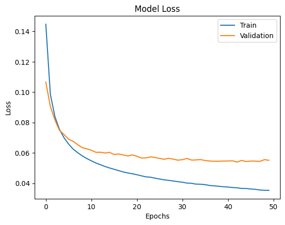

```
500/500 ━━━━━━━━━━━━━━━━━━━━ 0s 718us/step
125/125 ━━━━━━━━━━━━━━━━━━━━ 0s 1ms/step
Model 1 — Training performance
```

|  | Accuracy | Recall | Precision | F1 Score |
| --- | --- | --- | --- | --- |
| 0 | 0.993625 | 0.894144 | 0.990025 | 0.939645 |

```
Model 1 — Validation performance
```

|  | Accuracy | Recall | Precision | F1 Score |
| --- | --- | --- | --- | --- |
| 0 | 0.9915 | 0.864865 | 0.979592 | 0.91866 |

```
Model 1 — Classification report (validation)
125/125 ━━━━━━━━━━━━━━━━━━━━ 0s 1ms/step
              precision    recall  f1-score   support

         0.0       0.99      1.00      1.00      3778
         1.0       0.98      0.86      0.92       222

    accuracy                           0.99      4000
   macro avg       0.99      0.93      0.96      4000
weighted avg       0.99      0.99      0.99      4000
```

```python
# ============================================================
# 10. MODEL 1 — DEEPER NETWORK
#    Purpose: check if added depth improves validation metrics
# ============================================================

tf.keras.backend.clear_session()
model_1 = Sequential()
model_1.add(Dense(32, activation="relu", input_dim=input_dim))
model_1.add(Dense(16, activation="relu"))
model_1.add(Dense(1, activation="sigmoid"))

optimizer = tf.keras.optimizers.SGD()
model_1.compile(loss="binary_crossentropy", optimizer=optimizer, metrics=["accuracy"])

history_1 = model_1.fit(
    X_train,
    y_train,
    validation_data=(X_val, y_val),
    epochs=epochs,
    batch_size=batch_size,
    verbose=0,
)

plot_history(history_1, "loss")

model_1_train_perf = model_performance_classification(model_1, X_train, y_train)
model_1_val_perf   = model_performance_classification(model_1, X_val, y_val)

print("Model 1 — Training performance")
display(model_1_train_perf)
print("\nModel 1 — Validation performance")
display(model_1_val_perf)

print("\nModel 1 — Classification report (validation)")
y_val_pred_1 = (model_1.predict(X_val) > 0.5).astype(int)
print(classification_report(y_val, y_val_pred_1))
```

**Summary**

In order to capture more complex relationships, a second hidden layer was added.

### **11. Model 2 – Regularized Network (Dropout)**

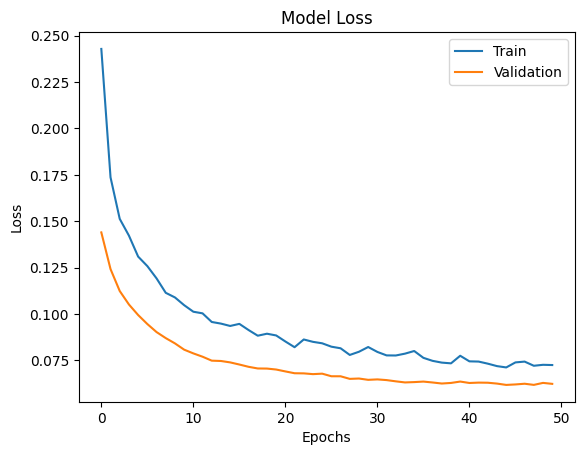

```
500/500 ━━━━━━━━━━━━━━━━━━━━ 0s 742us/step
125/125 ━━━━━━━━━━━━━━━━━━━━ 0s 832us/step
Model 2 — Training performance
```

|  | Accuracy | Recall | Precision | F1 Score |
| --- | --- | --- | --- | --- |
| 0 | 0.988437 | 0.807432 | 0.980848 | 0.885732 |

```
Model 2 — Validation performance
```

|  | Accuracy | Recall | Precision | F1 Score |
| --- | --- | --- | --- | --- |
| 0 | 0.988 | 0.815315 | 0.962766 | 0.882927 |

```
Model 2 — Classification report (validation)
125/125 ━━━━━━━━━━━━━━━━━━━━ 0s 857us/step
              precision    recall  f1-score   support

         0.0       0.99      1.00      0.99      3778
         1.0       0.96      0.82      0.88       222

    accuracy                           0.99      4000
   macro avg       0.98      0.91      0.94      4000
weighted avg       0.99      0.99      0.99      4000
```

```python
# ============================================================
# 11. MODEL 2 — REGULARIZED NETWORK (DROPOUT)
#    Purpose: reduce overfitting observed in deeper models
# ============================================================

from tensorflow.keras.layers import Dropout

tf.keras.backend.clear_session()
model_2 = Sequential()
model_2.add(Dense(32, activation="relu", input_dim=input_dim))
model_2.add(Dropout(0.5))
model_2.add(Dense(16, activation="relu"))
model_2.add(Dense(8, activation="relu"))
model_2.add(Dense(1, activation="sigmoid"))

optimizer = tf.keras.optimizers.SGD()
model_2.compile(loss="binary_crossentropy", optimizer=optimizer, metrics=["accuracy"])

history_2 = model_2.fit(
    X_train,
    y_train,
    validation_data=(X_val, y_val),
    epochs=epochs,
    batch_size=batch_size,
    verbose=0,
)

plot_history(history_2, "loss")

model_2_train_perf = model_performance_classification(model_2, X_train, y_train)
model_2_val_perf   = model_performance_classification(model_2, X_val, y_val)

print("Model 2 — Training performance")
display(model_2_train_perf)
print("\nModel 2 — Validation performance")
display(model_2_val_perf)

print("\nModel 2 — Classification report (validation)")
y_val_pred_2 = (model_2.predict(X_val) > 0.5).astype(int)
print(classification_report(y_val, y_val_pred_2))
```

**Summary**

In order to enhance generalization and prevent overfitting, dropout regularization was applied between layers.

### **12. Class Weights for Imbalance**

```python
# ============================================================
# 12. CLASS WEIGHTS FOR IMBALANCE
#    Purpose: give the minority class higher importance
# ============================================================

class_counts = np.bincount(y_train.astype(int))
class_weights = (y_train.shape[0]) / class_counts
class_weight_dict = {i: class_weights[i] for i in range(len(class_weights))}

print("Class weights computed from training data:")
print(class_weight_dict)
```

```
Class weights computed from training data:
{0: np.float64(1.0587612493382743), 1: np.float64(18.01801801801802)}
```

**Summary**

In order to handle the heavy imbalance, class weights were computed to give higher importance to failure predictions.

**Observations**: The calculated weighting increased focus on the minority class, ensuring later models would better prioritize failure detection over overall accuracy.

### **13. Model 3 – Regularized + Class Weights**

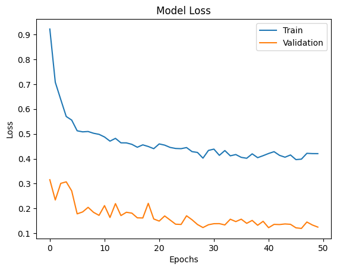

```
500/500 ━━━━━━━━━━━━━━━━━━━━ 0s 767us/step
125/125 ━━━━━━━━━━━━━━━━━━━━ 0s 955us/step
Model 3 — Training performance
```

|  | Accuracy | Recall | Precision | F1 Score |
| --- | --- | --- | --- | --- |
| 0 | 0.985313 | 0.911036 | 0.838342 | 0.873179 |

```
Model 3 — Validation performance
```

|  | Accuracy | Recall | Precision | F1 Score |
| --- | --- | --- | --- | --- |
| 0 | 0.98525 | 0.882883 | 0.855895 | 0.86918 |

```
Model 3 — Classification report (validation)
125/125 ━━━━━━━━━━━━━━━━━━━━ 0s 879us/step
              precision    recall  f1-score   support

         0.0       0.99      0.99      0.99      3778
         1.0       0.86      0.88      0.87       222

    accuracy                           0.99      4000
   macro avg       0.92      0.94      0.93      4000
weighted avg       0.99      0.99      0.99      4000
```

```python
# ============================================================
# 13. MODEL 3 — REGULARIZED + CLASS WEIGHTS
#    Purpose: improve recall on the failure class
# ============================================================

tf.keras.backend.clear_session()
model_3 = Sequential()
model_3.add(Dense(32, activation="relu", input_dim=input_dim))
model_3.add(Dropout(0.5))
model_3.add(Dense(16, activation="relu"))
model_3.add(Dense(8, activation="relu"))
model_3.add(Dense(1, activation="sigmoid"))

optimizer = tf.keras.optimizers.SGD()
model_3.compile(loss="binary_crossentropy", optimizer=optimizer, metrics=["accuracy"])

history_3 = model_3.fit(
    X_train,
    y_train,
    validation_data=(X_val, y_val),
    epochs=epochs,
    batch_size=batch_size,
    class_weight=class_weight_dict,
    verbose=0,
)

plot_history(history_3, "loss")

model_3_train_perf = model_performance_classification(model_3, X_train, y_train)
model_3_val_perf   = model_performance_classification(model_3, X_val, y_val)

print("Model 3 — Training performance")
display(model_3_train_perf)
print("\nModel 3 — Validation performance")
display(model_3_val_perf)

print("\nModel 3 — Classification report (validation)")
y_val_pred_3 = (model_3.predict(X_val) > 0.5).astype(int)
print(classification_report(y_val, y_val_pred_3))
```

**Summary**

In order to improve minority detection, the regularized network was retrained using class weights.

### **4. Model 4 – Change Optimizer to Adam**

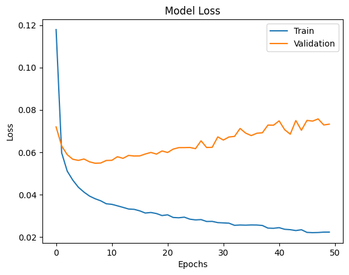

```
500/500 ━━━━━━━━━━━━━━━━━━━━ 0s 744us/step
125/125 ━━━━━━━━━━━━━━━━━━━━ 0s 776us/step
Model 4 — Training performance
```

|  | Accuracy | Recall | Precision | F1 Score |
| --- | --- | --- | --- | --- |
| 0 | 0.995563 | 0.927928 | 0.991576 | 0.958697 |

```
Model 4 — Validation performance
```

|  | Accuracy | Recall | Precision | F1 Score |
| --- | --- | --- | --- | --- |
| 0 | 0.992 | 0.882883 | 0.970297 | 0.924528 |

```
Model 4 — Classification report (validation)
125/125 ━━━━━━━━━━━━━━━━━━━━ 0s 798us/step
              precision    recall  f1-score   support

         0.0       0.99      1.00      1.00      3778
         1.0       0.97      0.88      0.92       222

    accuracy                           0.99      4000
   macro avg       0.98      0.94      0.96      4000
weighted avg       0.99      0.99      0.99      4000
```

```python
# ============================================================
# 14. MODEL 4 — CHANGE OPTIMIZER TO ADAM
#    Purpose: check if a different optimizer improves convergence
# ============================================================

tf.keras.backend.clear_session()
model_4 = Sequential()
model_4.add(Dense(32, activation="relu", input_dim=input_dim))
model_4.add(Dense(16, activation="relu"))
model_4.add(Dense(1, activation="sigmoid"))

optimizer = tf.keras.optimizers.Adam()
model_4.compile(loss="binary_crossentropy", optimizer=optimizer, metrics=["accuracy"])

history_4 = model_4.fit(
    X_train,
    y_train,
    validation_data=(X_val, y_val),
    epochs=epochs,
    batch_size=batch_size,
    verbose=0,
)

plot_history(history_4, "loss")

model_4_train_perf = model_performance_classification(model_4, X_train, y_train)
model_4_val_perf   = model_performance_classification(model_4, X_val, y_val)

print("Model 4 — Training performance")
display(model_4_train_perf)
print("\nModel 4 — Validation performance")
display(model_4_val_perf)

print("\nModel 4 — Classification report (validation)")
y_val_pred_4 = (model_4.predict(X_val) > 0.5).astype(int)
print(classification_report(y_val, y_val_pred_4))
```

**Summary**

In order to speed up convergence and improve stability, the optimizer was switched from SGD to Adam.

### **15. Model 5 – Deeper Network with Dropout (Adam)**

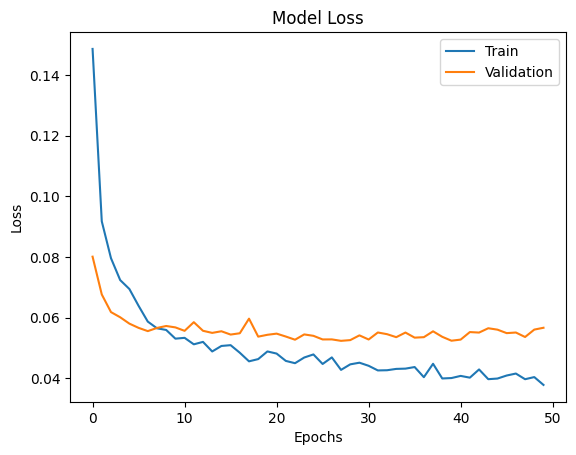

```
500/500 ━━━━━━━━━━━━━━━━━━━━ 0s 716us/step
125/125 ━━━━━━━━━━━━━━━━━━━━ 0s 864us/step
Model 5 — Training performance
```

|  | Accuracy | Recall | Precision | F1 Score |
| --- | --- | --- | --- | --- |
| 0 | 0.994188 | 0.899775 | 0.995019 | 0.945003 |

```
Model 5 — Validation performance
```

|  | Accuracy | Recall | Precision | F1 Score |
| --- | --- | --- | --- | --- |
| 0 | 0.9915 | 0.864865 | 0.979592 | 0.91866 |

```
Model 5 — Classification report (validation)
125/125 ━━━━━━━━━━━━━━━━━━━━ 0s 812us/step
              precision    recall  f1-score   support

         0.0       0.99      1.00      1.00      3778
         1.0       0.98      0.86      0.92       222

    accuracy                           0.99      4000
   macro avg       0.99      0.93      0.96      4000
weighted avg       0.99      0.99      0.99      4000
```

```python
# ============================================================
# 15. MODEL 5 — DEEPER NETWORK WITH DROPOUT (ADAM)
#    Purpose: combine depth, regularization, and a stronger optimizer
# ============================================================

tf.keras.backend.clear_session()
model_5 = Sequential()
model_5.add(Dense(64, activation="relu", input_dim=input_dim))
model_5.add(Dropout(0.5))
model_5.add(Dense(32, activation="relu"))
model_5.add(Dense(16, activation="relu"))
model_5.add(Dense(1, activation="sigmoid"))

optimizer = tf.keras.optimizers.Adam()
model_5.compile(loss="binary_crossentropy", optimizer=optimizer, metrics=["accuracy"])

history_5 = model_5.fit(
    X_train,
    y_train,
    validation_data=(X_val, y_val),
    epochs=epochs,
    batch_size=batch_size,
    verbose=0,
)

plot_history(history_5, "loss")

model_5_train_perf = model_performance_classification(model_5, X_train, y_train)
model_5_val_perf   = model_performance_classification(model_5, X_val, y_val)

print("Model 5 — Training performance")
display(model_5_train_perf)
print("\nModel 5 — Validation performance")
display(model_5_val_perf)

print("\nModel 5 — Classification report (validation)")
y_val_pred_5 = (model_5.predict(X_val) > 0.5).astype(int)
print(classification_report(y_val, y_val_pred_5))
```

**Summary**

### **16. Model 6 – Deeper + Class Weights (SGD)**

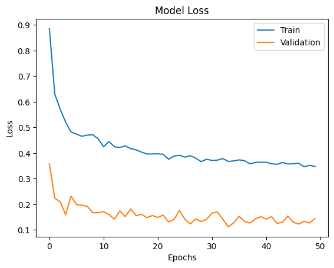

```
500/500 ━━━━━━━━━━━━━━━━━━━━ 1s 1ms/step
125/125 ━━━━━━━━━━━━━━━━━━━━ 0s 1ms/step
Model 6 — Training performance
```

|  | Accuracy | Recall | Precision | F1 Score |
| --- | --- | --- | --- | --- |
| 0 | 0.985125 | 0.917793 | 0.831633 | 0.872591 |

```
Model 6 — Validation performance
```

|  | Accuracy | Recall | Precision | F1 Score |
| --- | --- | --- | --- | --- |
| 0 | 0.9855 | 0.905405 | 0.844538 | 0.873913 |

```
Model 6 — Classification report (validation)
125/125 ━━━━━━━━━━━━━━━━━━━━ 0s 797us/step
              precision    recall  f1-score   support

         0.0       0.99      0.99      0.99      3778
         1.0       0.84      0.91      0.87       222

    accuracy                           0.99      4000
   macro avg       0.92      0.95      0.93      4000
weighted avg       0.99      0.99      0.99      4000
```

```python
# ============================================================
# 16. MODEL 6 — DEEPER + CLASS WEIGHTS (SGD)
#    Purpose: deeper model but still correcting for imbalance
# ============================================================

tf.keras.backend.clear_session()
model_6 = Sequential()
model_6.add(Dense(64, activation="relu", input_dim=input_dim))
model_6.add(Dropout(0.5))
model_6.add(Dense(32, activation="relu"))
model_6.add(Dense(16, activation="relu"))
model_6.add(Dense(1, activation="sigmoid"))

optimizer = tf.keras.optimizers.SGD()
model_6.compile(loss="binary_crossentropy", optimizer=optimizer, metrics=["accuracy"])

history_6 = model_6.fit(
    X_train,
    y_train,
    validation_data=(X_val, y_val),
    epochs=epochs,
    batch_size=batch_size,
    class_weight=class_weight_dict,
    verbose=0,
)

plot_history(history_6, "loss")

model_6_train_perf = model_performance_classification(model_6, X_train, y_train)
model_6_val_perf   = model_performance_classification(model_6, X_val, y_val)

print("Model 6 — Training performance")
display(model_6_train_perf)
print("\nModel 6 — Validation performance")
display(model_6_val_perf)

print("\nModel 6 — Classification report (validation)")
y_val_pred_6 = (model_6.predict(X_val) > 0.5).astype(int)
print(classification_report(y_val, y_val_pred_6))
```

**Summary**

In order to test optimizer impact, the same deep model was retrained using SGD.

### **17. Model Performance Comparison**

```python
# ============================================================
# 17. MODEL PERFORMANCE COMPARISON
#    Purpose: identify the best-performing model
# ============================================================

train_perf_comp = pd.concat(
    [
        model_0_train_perf.T,
        model_1_train_perf.T,
        model_2_train_perf.T,
        model_3_train_perf.T,
        model_4_train_perf.T,
        model_5_train_perf.T,
        model_6_train_perf.T,
    ],
    axis=1,
)
train_perf_comp.columns = [
    "Model 0",
    "Model 1",
    "Model 2",
    "Model 3",
    "Model 4",
    "Model 5",
    "Model 6",
]

val_perf_comp = pd.concat(
    [
        model_0_val_perf.T,
        model_1_val_perf.T,
        model_2_val_perf.T,
        model_3_val_perf.T,
        model_4_val_perf.T,
        model_5_val_perf.T,
        model_6_val_perf.T,
    ],
    axis=1,
)
val_perf_comp.columns = [
    "Model 0",
    "Model 1",
    "Model 2",
    "Model 3",
    "Model 4",
    "Model 5",
    "Model 6",
]

print("Training set performance comparison:")
display(train_perf_comp)

print("Validation set performance comparison:")
display(val_perf_comp)
```

```
Training set performance comparison:
```

|  | Model 0 | Model 1 | Model 2 | Model 3 | Model 4 | Model 5 | Model 6 |
| --- | --- | --- | --- | --- | --- | --- | --- |
| Accuracy | 0.988250 | 0.993625 | 0.988437 | 0.985313 | 0.995563 | 0.994188 | 0.985125 |
| Recall | 0.820946 | 0.894144 | 0.807432 | 0.911036 | 0.927928 | 0.899775 | 0.917793 |
| Precision | 0.961741 | 0.990025 | 0.980848 | 0.838342 | 0.991576 | 0.995019 | 0.831633 |
| F1 Score | 0.885784 | 0.939645 | 0.885732 | 0.873179 | 0.958697 | 0.945003 | 0.872591 |

```
Validation set performance comparison:
```

|  | Model 0 | Model 1 | Model 2 | Model 3 | Model 4 | Model 5 | Model 6 |
| --- | --- | --- | --- | --- | --- | --- | --- |
| Accuracy | 0.987250 | 0.991500 | 0.988000 | 0.985250 | 0.992000 | 0.991500 | 0.985500 |
| Recall | 0.810811 | 0.864865 | 0.815315 | 0.882883 | 0.882883 | 0.864865 | 0.905405 |
| Precision | 0.952381 | 0.979592 | 0.962766 | 0.855895 | 0.970297 | 0.979592 | 0.844538 |
| F1 Score | 0.875912 | 0.918660 | 0.882927 | 0.869180 | 0.924528 | 0.918660 | 0.873913 |

**Summary**

In order to evaluate all outcomes, results from every model were reviewed side by side.

### **18. Test Set Evaluation**

```python
# ============================================================
# 18. TEST SET EVALUATION
#    Purpose: check generalization of the selected model
# ============================================================

# Select the model based on validation performance
best_model = model_5  # update this if another model performs better

test_perf = model_performance_classification(best_model, X_test, y_test)
print("Test set performance for the selected model:")
display(test_perf)

print("\nClassification report — test set")
y_test_pred = (best_model.predict(X_test) > 0.5).astype(int)
print(classification_report(y_test, y_test_pred))
```

```
157/157 ━━━━━━━━━━━━━━━━━━━━ 0s 984us/step
Test set performance for the selected model:
```

|  | Accuracy | Recall | Precision | F1 Score |
| --- | --- | --- | --- | --- |
| 0 | 0.9914 | 0.858156 | 0.987755 | 0.918406 |

```
Classification report — test set
157/157 ━━━━━━━━━━━━━━━━━━━━ 0s 871us/step
              precision    recall  f1-score   support

         0.0       0.99      1.00      1.00      4718
         1.0       0.99      0.86      0.92       282

    accuracy                           0.99      5000
   macro avg       0.99      0.93      0.96      5000
weighted avg       0.99      0.99      0.99      5000
```

**Summary**

In order to validate generalization to unseen data, Model 5 was evaluated on the test set.

### **Expanded Executive Summary**

The goal of this initiative was to develop a model that predicts generator failures in wind turbines before they occur — enabling planned maintenance instead of costly emergency replacements. The dataset contained 20,000 training records and 5,000 test records, each representing turbine sensor readings across 40 performance variables. The target was binary (1 = failure, 0 = no failure), with only 5.5% of turbines failing, making it a highly imbalanced classification challenge.

The model’s performance means it correctly anticipates over four out of five real turbine failures in advance. From a financial standpoint, this has major implications. Replacing a single turbine typically costs $2.5 - $4 million, while preventive maintenance interventions cost a small fraction of that; typically less than than $40 per kilowatt annually, or under $30,000 per turbine). Unplanned downtime can also cost between $3,000 and $17,000 per day depending on site conditions and capacity.

By accurately identifying turbines at risk before failure, this model reduces emergency replacements, lowers downtime losses, and allows maintenance scheduling around low-demand periods. For a fleet of just 100 turbines, avoiding even a handful of unexpected failures could represent $10–$20 million in prevented replacement and downtime costs annually.

This solution positions predictive analytics as a key driver of asset longevity and cost efficiency in wind energy operations, demonstrating measurable financial value and operational impact.